# Praca projektowa nr 3

## Zapytanie 3

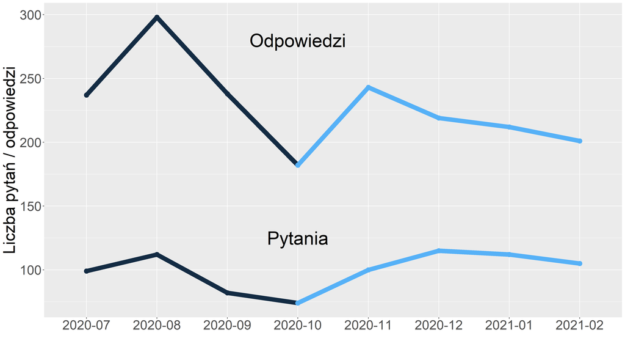

## Zapytanie 4

**Wzory wykorzystywane do obliczenia wartości trendu** \[ \gamma(x) = \left\{ \begin{array}{ll} \frac{ViewCount}{Score} & \textrm{jeśli $Score \neq 0$}\\ \frac{ViewCount}{Score+1} & \textrm{jeśli $Score = 0$}\\ \end{array} \right. \]

\[ Punkty Trendu(x) = \left\{ \begin{array}{ll} Score & \textrm{jeśli $x$ jest odpowiedzią}\\ \gamma(x) & \textrm{jeśli $x$ nie jest odpowiedzią}\\ \end{array} \right. \]

\[ Punkty Trendu Forum(y) = \sum_{i = w_1}^{w_n} Punkty Trendu(i) \] gdzie:

- \(w_i\) to i-ty wiersz ramki Posts z serwisu y;
- \(i\in[n]\);
- \(n\) - liczba wierszy ramki Posts z serwisu y.

## Zapytanie 4

**Porównanie popularności wybranych serwisów: *Arqade*, *Chess*, *Board & Card Games***

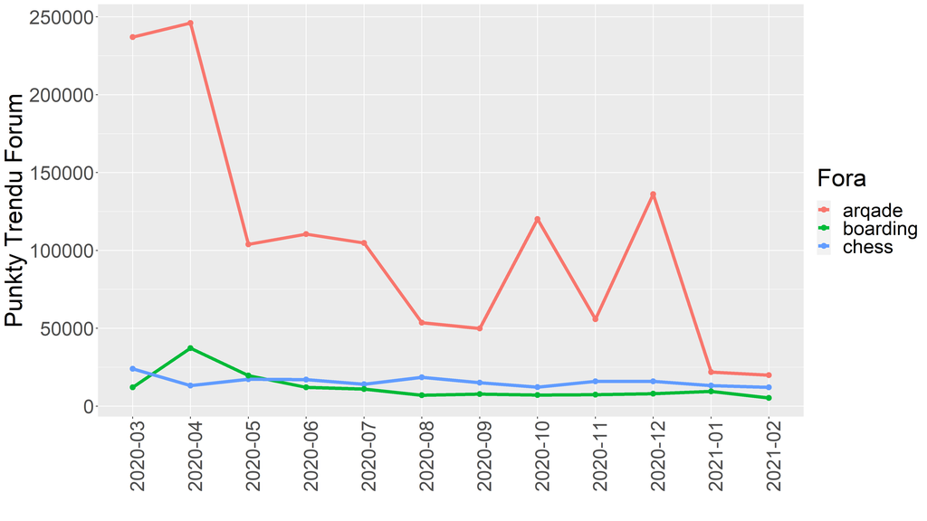

## Chwila na mema

[figure not shown]